# Loan_Data

## Scatter Plot 2

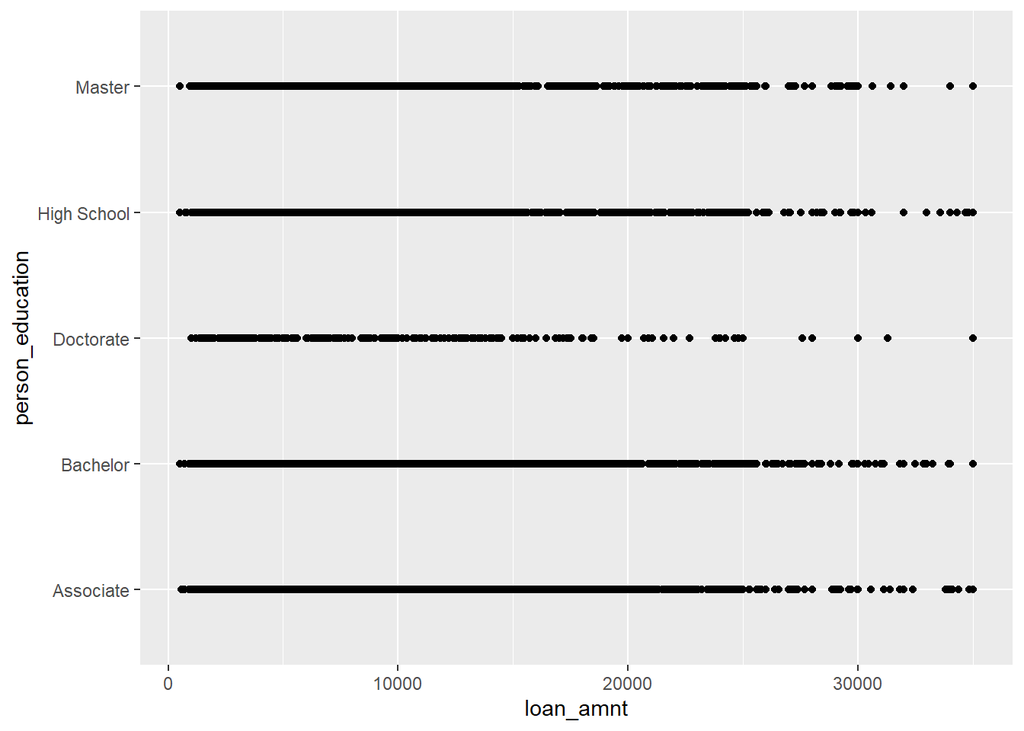

```r
library(ggplot2)
ggplot(loandata, aes(x = loan_amnt, y = person_education)) + geom_point()
```

Το ποσό δανείου κατανέμεται ομοιόμορφα μεταξύ των επιπέδων εκπαίδευσης.

Δεν φαίνεται ξεκάθαρη σχέση μεταξύ επιπέδου εκπαίδευσης και ποσού δανείου.

Πιθανώς απαιτείται διαφορετική απεικόνιση (π.χ. boxplot) για να διερευνηθεί καλύτερα η κατανομή των ποσών ανά κατηγορία.

## Box Plot

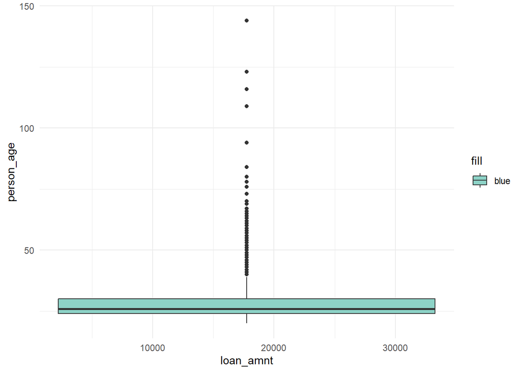

```r
ggplot(loandata, aes(x = loan_amnt, y = person_age, fill = "blue")) +
  geom_boxplot() +
  theme_minimal() +
  scale_fill_brewer(palette = "Set3")
```

Τα περισσότερα δεδομένα βρίσκονται κοντά στον πυθμένα του boxplot, υποδηλώνοντας ότι το μεγαλύτερο μέρος των δανείων αφορά άτομα σε χαμηλότερες ηλικίες.

Υπάρχουν σημαντικά outliers σε υψηλές ηλικίες, που ίσως χρειάζονται περαιτέρω ανάλυση.

Η διανομή του ποσού δανείου φαίνεται συγκεντρωμένη σε μια συγκεκριμένη περιοχή με λίγες εξαιρέσεις.

## Histogram

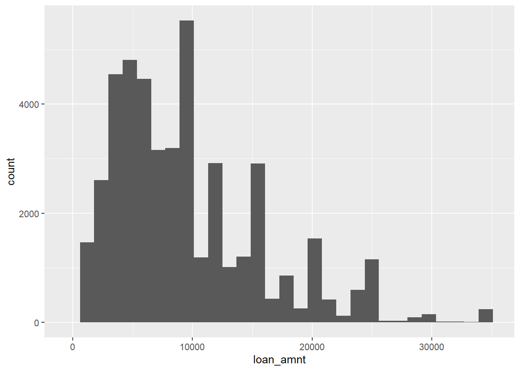

```r
ggplot(loandata, aes(loan_amnt)) +
      geom_histogram()
```

Τα περισσότερα δάνεια φαίνεται να είναι συγκεντρωμένα σε χαμηλότερα ποσά (κάτω από 15.000). Υπάρχουν επίσης μερικές κορυφές (spikes), πιθανότατα λόγω συγκεκριμένων σταθερών ποσών δανείου που επιλέγονται συχνά. Διασπορά και Συμμετρία Το διάγραμμα δείχνει μια ασύμμετρη κατανομή, με ουρά προς τα δεξιά (δεξιά λοξότητα). Αυτό σημαίνει ότι υπάρχουν μερικά δάνεια με πολύ υψηλά ποσά, αλλά είναι λιγότερο συχνά. Ρυθμίσεις του Histogram Η προεπιλεγμένη τιμή bins = 30 έχει χρησιμοποιηθεί για την ομαδοποίηση των δεδομένων. Ενδέχεται να χρειαστεί προσαρμογή της παραμέτρου binwidth για πιο ομαλή παρουσίαση.

## Barchart

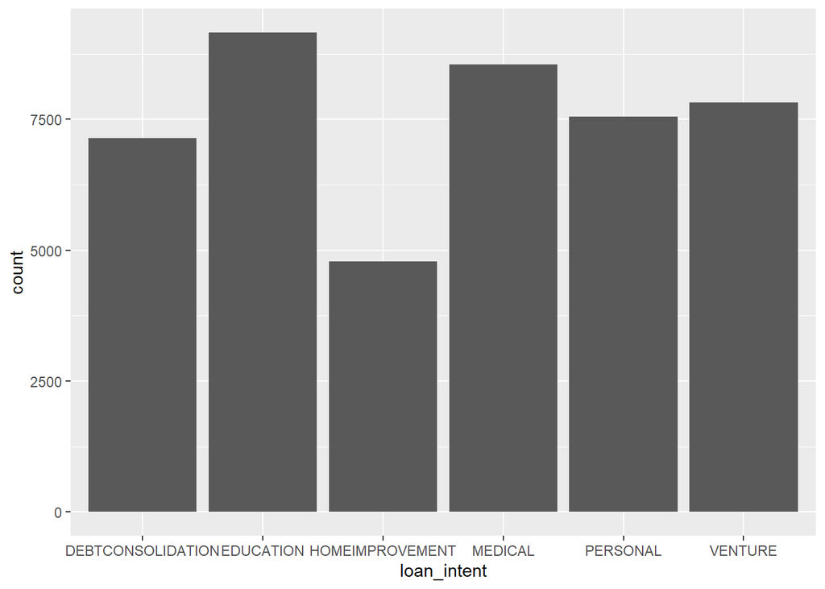

```r
ggplot(loandata, aes(loan_intent)) +
      geom_bar()
```

Εκπαίδευση (EDUCATION) και Ιατρικά Έξοδα (MEDICAL) είναι από τους πιο συχνούς σκοπούς δανείων. Η κατηγορία HOMEIMPROVEMENT έχει το μικρότερο αριθμό δανείων, δηλώνοντας ότι λιγότεροι δανειολήπτες παίρνουν δάνειο για ανακαίνιση σπιτιού. Οι υπόλοιπες κατηγορίες έχουν σχετικά ισοκατανεμημένο αριθμό δανείων, χωρίς μεγάλες διαφορές μεταξύ τους. Συμπέρασμα Το διάγραμμα μας βοηθά να κατανοήσουμε τις προτεραιότητες των δανειοληπτών. Παρατηρούμε ότι οι πιο συχνοί λόγοι λήψης δανείων σχετίζονται με εκπαίδευση και ιατρικά έξοδα, ενώ οι λιγότεροι δανειολήπτες επιλέγουν δάνεια για βελτίωση κατοικίας

## Γραμμική Παλινδρόμηση

### Model 1 - Ποσό δανείου

```r
model1 <- lm(person_age ~ loan_amnt, data = loandata)
summary(model1)
```

```
##
## Call:
## lm(formula = person_age ~ loan_amnt, data = loandata)
##
## Residuals:
##     Min      1Q  Median      3Q     Max
##  -8.477  -4.270  -1.663   2.410 116.468
##
## Coefficients:
##              Estimate Std. Error t value Pr(>|t|)
## (Intercept) 2.730e+01  5.172e-02  527.77   <2e-16 ***
## loan_amnt   4.858e-05  4.507e-06   10.78   <2e-16 ***
## ---
## Signif. codes:  0 '***' 0.001 '**' 0.01 '*' 0.05 '.' 0.1 ' ' 1
##
## Residual standard error: 6.037 on 44998 degrees of freedom
## Multiple R-squared:  0.002576,   Adjusted R-squared:  0.002553
## F-statistic: 116.2 on 1 and 44998 DF,  p-value: < 2.2e-16
```

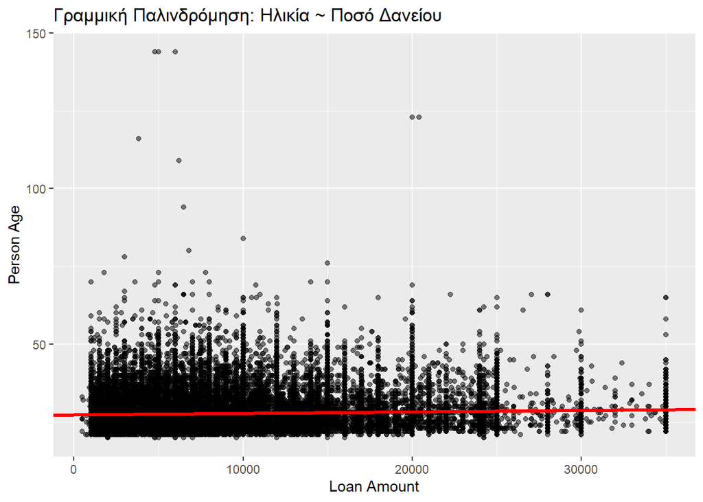

```r
ggplot(loandata, aes(x = loan_amnt, y = person_age)) +
  geom_point(alpha = 0.5) +
  geom_abline(intercept = coef(model1)[1], slope = coef(model1)[2], color = "red", linewidth = 1.2) +
  labs(title = "Γραμμική Παλινδρόμηση: Ηλικία ~ Ποσό Δανείου",
       x = "Loan Amount", y = "Person Age")
```

**Σχόλιο:** Το διάγραμμα παρουσιάζει τη γραμμική παλινδρόμηση της ηλικίας σε σχέση με το ποσό δανείου. Από την κατανομή των σημείων φαίνεται ότι υπάρχει μεγάλη συγκέντρωση ατόμων με χαμηλά ποσά δανείων, κυρίως κάτω από τις 10.000 μονάδες, ενώ οι ηλικίες κυμαίνονται κυρίως μεταξύ 20 και 60 ετών. Η κόκκινη γραμμή παλινδρόμησης είναι σχεδόν οριζόντια, γεγονός που υποδηλώνει ότι δεν υπάρχει ουσιαστική γραμμική συσχέτιση μεταξύ της ηλικίας και του ποσού δανείου. Συνεπώς, μπορούμε να συμπεράνουμε πως η ηλικία δεν επηρεάζει εμφανώς το ποσό του δανείου, τουλάχιστον με γραμμικό τρόπο.

### Model 2 - Προσθήκη person_income

```r
model2 <- lm(person_age ~ loan_amnt + person_income , data = loandata)
summary(model2)
```

```
##
## Call:
## lm(formula = person_age ~ loan_amnt + person_income, data = loandata)
##
## Residuals:
##     Min      1Q  Median      3Q     Max
## -20.067  -4.129  -1.700   2.365 113.916
##
## Coefficients:
##                Estimate Std. Error t value Pr(>|t|)
## (Intercept)   2.656e+01  5.397e-02 492.222   <2e-16 ***
## loan_amnt     3.883e-06  4.563e-06   0.851    0.395
## person_income 1.449e-05  3.583e-07  40.428   <2e-16 ***
## ---
## Signif. codes:  0 '***' 0.001 '**' 0.01 '*' 0.05 '.' 0.1 ' ' 1
##
## Residual standard error: 5.931 on 44997 degrees of freedom
## Multiple R-squared:  0.03753,    Adjusted R-squared:  0.03749
## F-statistic: 877.4 on 2 and 44997 DF,  p-value: < 2.2e-16
```

**Σχόλιο:** Με την προσθήκη του person_income στο μοντέλο, παρατηρείται αξιοσημείωτη βελτίωση. Ο νέος συντελεστής για το person_income είναι στατιστικά σημαντικός (p-value < 2e-16) και έχει θετικό πρόσημο, υποδηλώνοντας ότι όσο αυξάνεται το εισόδημα, αυξάνεται και η ηλικία, κάτι που ίσως αντανακλά μια γενική τάση μεγαλύτερων ηλικιών να έχουν υψηλότερα εισοδήματα. Αντίθετα, το loan_amnt πλέον δεν είναι στατιστικά σημαντικό (p-value = 0.395), πράγμα που σημαίνει ότι μόλις προστεθεί το εισόδημα στο μοντέλο, η επίδραση του ποσού του δανείου στην ηλικία σχεδόν εξαφανίζεται. Η τιμή του R-squared αυξάνεται στο 0.0375, κάτι που δείχνει ότι το μοντέλο εξηγεί περίπου το 3.75% της διακύμανσης στην ηλικία — σαφώς βελτιωμένο σε σχέση με το προηγούμενο μοντέλο, αν και ακόμα σχετικά χαμηλό. Συνοπτικά, η προσθήκη του εισοδήματος βελτιώνει το μοντέλο και αναδεικνύει ότι το εισόδημα σχετίζεται πολύ πιο έντονα με την ηλικία από ό,τι το ποσό του δανείου.

```r
model3 <- lm(person_age ~ loan_amnt + person_income + person_education, data = loandata)
summary(model3)
```

```
##
## Call:
## lm(formula = person_age ~ loan_amnt + person_income + person_education,
##     data = loandata)
##
## Residuals:
##     Min      1Q  Median      3Q     Max
## -19.903  -4.068  -1.702   2.389 113.582
##
## Coefficients:
##                               Estimate Std. Error t value Pr(>|t|)
## (Intercept)                  2.696e+01  7.066e-02 381.560  < 2e-16 ***
## loan_amnt                    3.288e-06  4.526e-06   0.726    0.468
## person_income                1.440e-05  3.554e-07  40.503  < 2e-16 ***
## person_educationBachelor    -8.842e-01  7.389e-02 -11.967  < 2e-16 ***
## person_educationDoctorate    5.308e+00  2.421e-01  21.926  < 2e-16 ***
## person_educationHigh School -3.334e-01  7.594e-02  -4.390 1.14e-05 ***
## person_educationMaster      -6.707e-01  8.851e-02  -7.577 3.60e-14 ***
## ---
## Signif. codes:  0 '***' 0.001 '**' 0.01 '*' 0.05 '.' 0.1 ' ' 1
##
## Residual standard error: 5.882 on 44993 degrees of freedom
## Multiple R-squared:  0.05325,    Adjusted R-squared:  0.05313
## F-statistic: 421.8 on 6 and 44993 DF,  p-value: < 2.2e-16
```

```r
library(knitr)

model_summary <- data.frame(
  Μοντέλο = c(
    "Ηλικία ~ Ποσό Δανείου",
    "Ηλικία ~ Ποσό Δανείου + Εισόδημα",
    "Ηλικία ~ Ποσό Δανείου + Εισόδημα + Εκπαίδευση"
  ),
  R_squared = c(
    summary(model1)$r.squared,
    summary(model2)$r.squared,
    summary(model3)$r.squared
  ),
  SSE = c(
    deviance(model1),
    deviance(model2),
    deviance(model3)
  )
)

model_summary$R_squared <- round(model_summary$R_squared, 4)
model_summary$SSE <- round(model_summary$SSE, 2)

kable(model_summary, caption = "Σύγκριση Μοντέλων: R² και SSE")
```

Σύγκριση Μοντέλων: R² και SSE

| Μοντέλο | R_squared | SSE |
| --- | --- | --- |
| Ηλικία ~ Ποσό Δανείου | 0.0026 | 1640178 |
| Ηλικία ~ Ποσό Δανείου + Εισόδημα | 0.0375 | 1582692 |
| Ηλικία ~ Ποσό Δανείου + Εισόδημα + Εκπαίδευση | 0.0533 | 1556845 |

## Διαχωρισμός training και testing sets

```r
library(caTools)

set.seed(903)

split <- sample.split(loandata, SplitRatio = 0.65)

train_set <- subset(loandata, split == TRUE)
test_set  <- subset(loandata, split == FALSE)

train <- subset(loandata, split == TRUE)
test  <- subset(loandata, split == FALSE)

# Εκτύπωση αριθμού καταχωρήσεων σε κάθε set
cat("Αριθμός καταχωρήσεων στο training set:", nrow(train), "\n")
```

```
## Αριθμός καταχωρήσεων στο training set: 28928
```

```r
cat("Αριθμός καταχωρήσεων στο testing set:", nrow(test), "\n")
```

```
## Αριθμός καταχωρήσεων στο testing set: 16072
```

```r
# 1. Φόρτωση βιβλιοθηκών
# Φόρτωση απαραίτητων βιβλιοθηκών
library(dplyr)

# Δημιουργία του μοντέλου λογιστικής παλινδρόμησης
# Υποθέτουμε ότι το train set λέγεται "train" και η εξαρτημένη μεταβλητή είναι "target"
model <- glm(loan_status ~ ., data = train, family = binomial)

# Εμφάνιση συνοπτικών αποτελεσμάτων
summary(model)
```

```
##
## Call:
## glm(formula = loan_status ~ ., family = binomial, data = train)
##
## Coefficients:
##                                     Estimate Std. Error z value Pr(>|z|)
## (Intercept)                       -1.051e+00  4.483e-01  -2.344  0.01909 *
## person_age                         3.168e-02  1.364e-02   2.323  0.02018 *
## person_gendermale                  4.363e-02  4.413e-02   0.989  0.32283
## person_educationBachelor           3.551e-02  5.854e-02   0.607  0.54405
## person_educationDoctorate         -1.675e-01  1.881e-01  -0.890  0.37324
## person_educationHigh School        1.951e-02  6.097e-02   0.320  0.74899
## person_educationMaster             5.827e-02  7.009e-02   0.831  0.40580
## person_income                      5.517e-07  2.403e-07   2.296  0.02168 *
## person_emp_exp                    -3.164e-02  1.216e-02  -2.602  0.00926 **
## person_home_ownershipOTHER         5.944e-01  3.952e-01   1.504  0.13255
## person_home_ownershipOWN          -1.528e+00  1.279e-01 -11.951  < 2e-16 ***
## person_home_ownershipRENT          6.926e-01  4.990e-02  13.880  < 2e-16 ***
## loan_amnt                         -9.914e-05  4.918e-06 -20.158  < 2e-16 ***
## loan_intentEDUCATION              -9.314e-01  7.325e-02 -12.715  < 2e-16 ***
## loan_intentHOMEIMPROVEMENT         3.474e-02  8.168e-02   0.425  0.67062
## loan_intentMEDICAL                -3.162e-01  7.015e-02  -4.507 6.56e-06 ***
## loan_intentPERSONAL               -6.984e-01  7.500e-02  -9.312  < 2e-16 ***
## loan_intentVENTURE                -1.185e+00  7.889e-02 -15.020  < 2e-16 ***
## loan_int_rate                      3.418e-01  8.264e-03  41.356  < 2e-16 ***
## loan_percent_income                1.584e+01  3.843e-01  41.202  < 2e-16 ***
## cb_person_cred_hist_length        -3.637e-03  1.127e-02  -0.323  0.74691
## credit_score                      -8.214e-03  5.094e-04 -16.125  < 2e-16 ***
## previous_loan_defaults_on_fileYes -2.031e+01  1.281e+02  -0.159  0.87398
## ---
## Signif. codes:  0 '***' 0.001 '**' 0.01 '*' 0.05 '.' 0.1 ' ' 1
##
## (Dispersion parameter for binomial family taken to be 1)
##
##     Null deviance: 30646  on 28927  degrees of freedom
## Residual deviance: 12803  on 28905  degrees of freedom
## AIC: 12849
##
## Number of Fisher Scoring iterations: 19
```

*Σχόλιο:* Το μοντέλο λογιστικής παλινδρόμησης δείχνει ότι μεταβλητές όπως το επιτόκιο δανείου, το ποσοστό εισοδήματος που αφιερώνεται στο δάνειο, το ποσό του δανείου, η πιστοληπτική ικανότητα και ο σκοπός του δανείου έχουν ισχυρή και στατιστικά σημαντική συσχέτιση με την πιθανότητα έγκρισης του δανείου (p < 0.05).

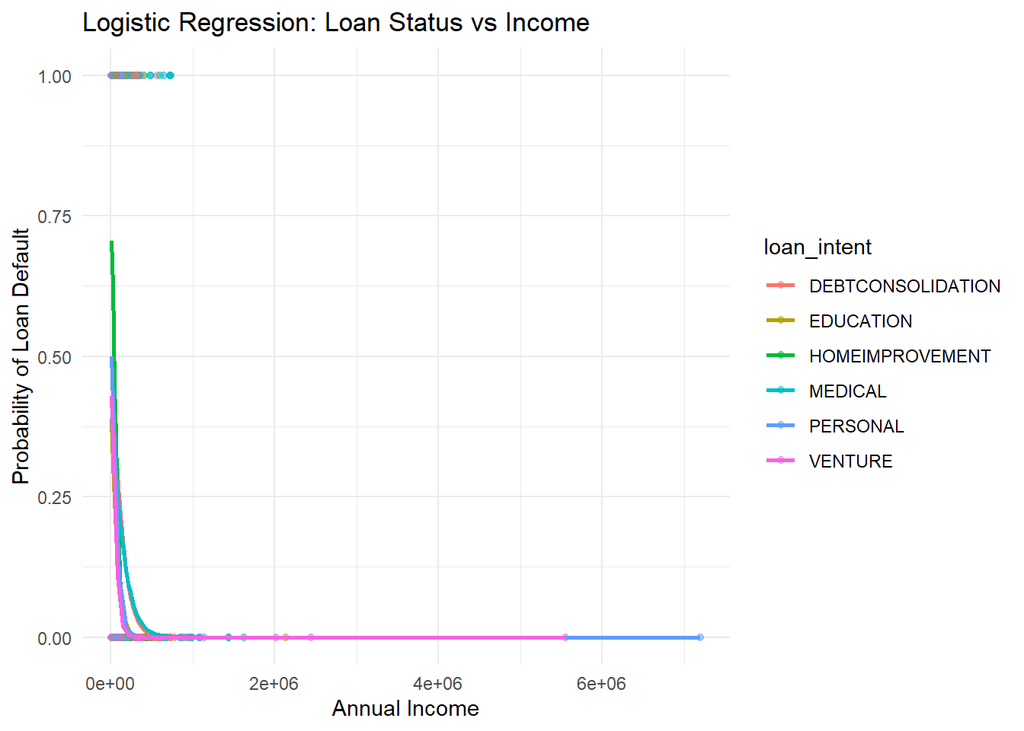

```r
ggplot(train, aes(x = person_income, y = loan_status, color = loan_intent)) +
  geom_point(alpha = 0.5) +
  geom_smooth(method = "glm", method.args = list(family = "binomial"), se = FALSE) +
  labs(title = "Logistic Regression: Loan Status vs Income",
       x = "Annual Income",
       y = "Probability of Loan Default") +
  theme_minimal()
```

```r
predictTest <- predict(model, newdata = test, type = "response")

predicted_class <- ifelse(predictTest > 0.5, 1, 0)
```